# Analyse en Composantes Principales

Jeu de données temperature

Ce jeu de données contient 35 individus et 17 variables, 3 variables quantitatives sont illustratives, 1 variable qualitative est illustrative, 4 individus sont illustratifs.

### 1. Observation d’individus extrêmes

L’analyse des graphes ne révèle aucun individu singulier.

### 2. Distribution de l’inertie

L’inertie des axes factoriels indique d’une part si les variables sont structurées et suggère d’autre part le nombre judicieux de composantes principales à étudier.

Les 2 premiers axes de l’ analyse expriment **92.89%** de l’inertie totale du jeu de données ; cela signifie que 92.89% de la variabilité totale du nuage des individus (ou des variables) est représentée dans ce plan. C’est un pourcentage très élevé, et le premier plan représente donc extrêmement bien la variabilité contenue dans l’ensemble du jeu de données actif. Cette valeur est nettement supérieure à la valeur référence de **35.43%**, la variabilité expliquée par ce plan est donc hautement significative (cette intertie de référence est le quantile 0.95-quantile de la distribution des pourcentages d’inertie obtenue en simulant 4299 jeux de données aléatoires de dimensions comparables sur la base d’une distribution normale).

Du fait de ces observations, il n’est pas nécessaire pour l’analyse d’interpréter les dimensions suivantes.

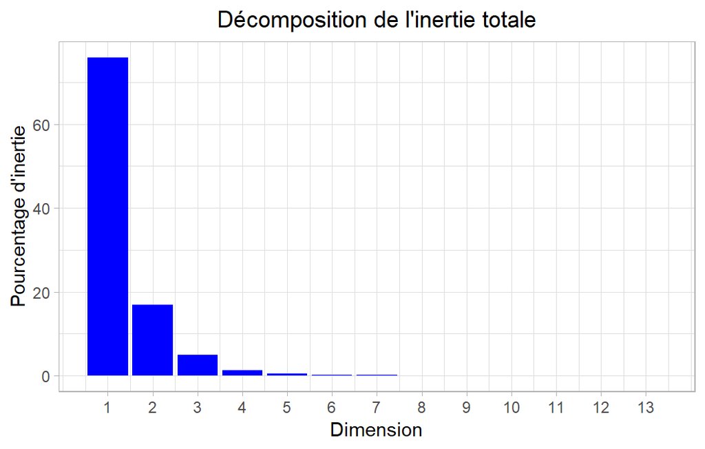

**Figure 2 - Décomposition de l’inertie totale** *Le premier facteur est prépondérant : il explique a lui seul 75.97% de la variabilité totale des données.* *Il convient de noter que dans un tel cas, la variabilité liée aux autres composantes peut être dénuée de sens, en dépit d’un pourcentage élevé.*

### 3. Description du plan 1:2

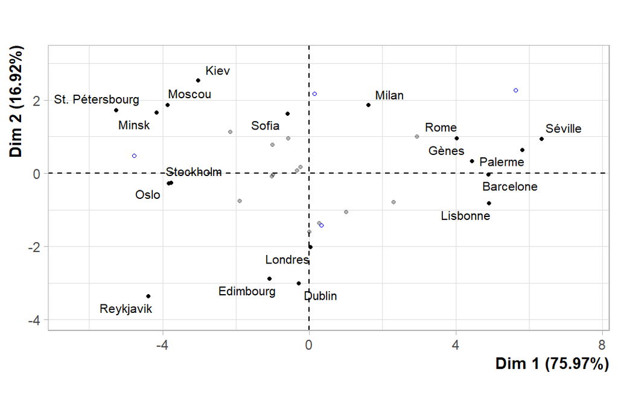

**Figure 3.1 - Graphe des individus (ACP)** *The individuals in black are considered as active whereas the individuals in blue are illustrative.* *Les individus libellés sont ceux ayant la plus grande contribution à la construction du plan.*

La probabilité critique du test de Wilks indique la variable dont les modalités sépare au mieux les individus sur le plan (i.e. qui explique au mieux les distances entre individus).

```
##    Région
## 0.7154821
```

Il n’y a qu’une unique variable qualitative possible pour illustrer les distances entre individus : *Région*.

[figure not shown]

**Figure 3.2 - Graphe des individus (ACP)** *Les individus libellés sont ceux ayant la plus grande contribution à la construction du plan.* *Les individus en italique représentés par un cercle vide sont les individus supplémentaires (illustratifs), ceux représentés par un point sont les individus actifs.* *Les individus sont colorés selon leur appartenance aux modalités de la variable* Région.

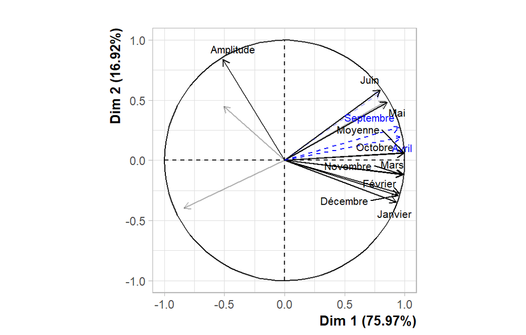

**Figure 3.3 - Graphe des variables (ACP)** *Les variables en noir sont les variables actives, celles en bleu sont les variables quantitatives supplémentaires (illustratives).* *Les variables libellées sont celles les mieux représentées sur le plan.*

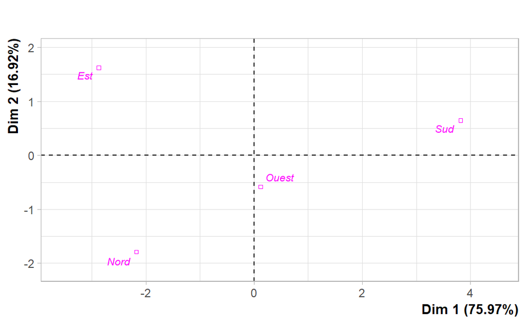

**Figure 3.4 - Graphe des modalités (ACP)** *Les facteurs libellés sont ceux les mieux représentés sur le plan.*

La **dimension 1** oppose des individus tels que *Séville*, *Barcelone*, *Rome*, *Lisbonne*, *Gènes* et *Palerme* (à droite du graphe, caractérisés par une coordonnée fortement positive sur l’axe) à des individus comme *Minsk*, *Stockholm*, *St. Pétersbourg*, *Oslo*, *Kiev* et *Reykjavik* (à gauche du graphe, caractérisés par une coordonnée fortement négative sur l’axe).

Le groupe auquel les individus *Séville*, *Barcelone*, *Rome*, *Lisbonne*, *Gènes* et *Palerme* appartiennent (caractérisés par une coordonnée positive sur l’axe) partage :

Le groupe auquel les individus *Minsk*, *Stockholm*, *St. Pétersbourg*, *Oslo*, *Kiev* et *Reykjavik* appartiennent (caractérisés par une coordonnées négative sur l’axe) partage :

### 4. Classification

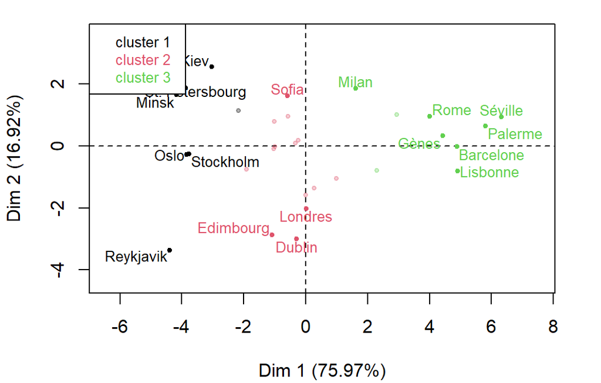

**Figure 4 - Classification Ascendante Hiérachique des individus.** *La classification réalisée sur les individus fait apparaître 3 classes.*

La **classe 1** est composée d’individus tels que *Kiev*, *Minsk*, *Moscou*, *Oslo*, *Reykjavik*, *Stockholm* et *St. Pétersbourg*. Ce groupe est caractérisé par :

- de fortes valeurs pour les variables *Longitude*, *Latitude* et *Amplitude* (de la plus extrême à la moins extrême).
- de faibles valeurs pour des variables telles que *Mars*, *Février*, *Janvier*, *Décembre*, *Novembre*, *Moyenne*, *Octobre*, *Avril*, *Septembre* et *Mai* (de la plus extrême à la moins extrême).

La **classe 2** est composée d’individus tels que *Dublin*, *Londres*, *Sofia* et *Edimbourg*. Ce groupe est caractérisé par :

- de faibles valeurs pour les variables *Juillet* et *Juin* (de la plus extrême à la moins extrême).

La **classe 3** est composée d’individus tels que *Lisbonne*, *Rome*, *Barcelone*, *Gènes*, *Milan*, *Palerme* et *Séville*. Ce groupe est caractérisé par :

- de fortes valeurs pour des variables telles que *Septembre*, *Moyenne*, *Octobre*, *Août*, *Avril*, *Juillet*, *Novembre*, *Juin*, *Mars* et *Mai* (de la plus extrême à la moins extrême).
- de faibles valeurs pour la variable *Latitude*.